# Coursework Report

*N* removed NAs: 2

*N* removed <18: 18

*N* total clean: 128

| Group | *N* | *M*<sub>age</sub> | *M*<sub>rating</sub> |
| --- | --- | --- | --- |
| Control | 59 | 20.51 | 7.19 |
| Experim | 69 | 20.94 | 5.64 |

**Main analysis results**

*t*(126) = 12.5, *p* < .001

# Coursework Report

Analysing Data, Spring 2020

[output not shown]

# Results

Before analysing the data, I removed any inappropriate ages (below 18 or above 99) and any N/As in my data that could hinder the analysis of the results. To be able to perform the t-test, I created a composite score for each participant by adding together their means for each question and dividing it by the number of questions (three). The difference in the mean composite scores between the conditions is what the t-test will analyse.

Participants’ ratings of perceived attractiveness for the man was analysed by condition and by age. As seen in Table 1, the ages of participants in each condition were similar, but the experimental group had, on average, older participants and a broader range of ages (larger standard deviation). However, there is only a small difference so this still could indicate that age is probably not a factor in causing the difference in attractiveness rating between conditions.

As shown in Table 2, the mean attractiveness rating was higher in the control condition for all three questions than in the experimental condition. The white background therefore results in higher ratings of attractiveness. In both conditions, Question 2 resulted in the highest mean attractiveness. However, in the experimental condition, both questions 2 and 3 resulted in the same score. The results of question 3 had the biggest standard deviation out of the three question in both conditions. This means that the results from this question are further from the mean which could suggest that this question may be vague therefore, produces a wider range of answers.

*Table 2* Summary of mean ratings by Experimental condition

| Condition | Question 1 *M* | Question 1 *SD* | Question 2 *M* | Question 2 *SD* | Question 3 *M* | Question 3 *SD* |
| --- | --- | --- | --- | --- | --- | --- |
| Control | 7.15 | 1.17 | 7.41 | 1.18 | 7.0 | 1.29 |
| Experimental | 5.52 | 1.24 | 5.70 | 1.39 | 5.7 | 1.44 |

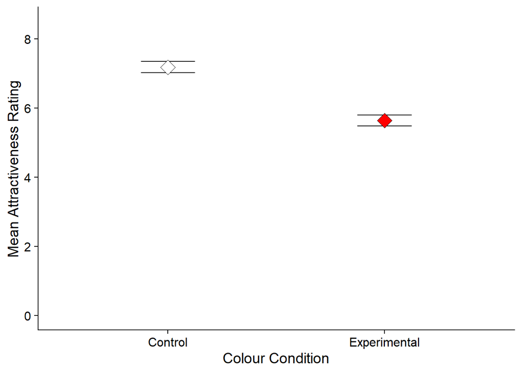

**Figure 1. The mean rating of attractiveness of a moderately attractive man after being viewed in a (control) white or (experimental) red coloured frame (1 -/+ SEM).**

# Discussion

From the results, i can conclude that the people in the two different experimental conditions represent samples from different populations, as they have different mean attractiveness ratings. Therefore, colour does make a difference in the average attractiveness rating of a moderately attractive man, where the control condition (white or no colour) results in higher attractiveness ratings and the experimental condition lowers the attractiveness rating.

In the original study by Elliot et al (2010), participants in the red condition perceived the man as more attractive, in comparison to those in the white condition. Elliot et al (2010) suggested that red is an indication of a strong masculine standing, in many non-human species, and that females have a mating preference for males of higher status. My results also showed a significant difference between the two conditions, but my findings had a reversed outcome, whereby participants in the white condition perceived the man as more attractive. While my findings contradict the original study, newer replications have produced similar results. For example, in Hesslinger et al (2015), participants in both colour conditions were found to provide incredibly similar ratings of perceived attractiveness with a small difference between the average ratings. However, there was no statistical significance for either males or females which shows red does not result in a higher attractiveness rating, meaning this study also contradicts the red effect on attractiveness. A potential explanation why red is not causing higher attractiveness in this replication study could be due to colour having different meanings in different contexts, which therefore triggers different ratings depending on the participants and situation. One solution for this is to perform larger sample studies to check the robustness of the red effect. For instance, the colour red may be associated with the Red-Light District or the flashing red fire engine lights which both have negative connotations and may therefore prompt individuals to keep their distance and therefore decrease the rating of perceived attractiveness of men associated with the colour red (Peperkoorn et al., 2016).

A strength of this experiment is that it used a between-subject design using random assignment to prevent participants from seeing both colour variations to stop them figuring out the experiment’s purpose. Consequently, the participants do not show demand characteristics which ensures that the findings will not be affected Furthermore, participants were limited to those without a colour deficiency (red-green and/or blue-yellow) to ensure that no variables interfered with the results (Elliot et al., 2010). However, it was mentioned in (Elliot & Maier, 2013) article that meta-analyses of psychological research have shown that studies with null results often end up unpublished (‘file draw problem’), so there could be further evidence indicating that there is no red effect as suggested by the results. Additionally, when considering the experiment’s approximate power (probability of rejecting the null hypothesis), this replication of Elliot’s analysis may have publication bias similar to the original experiment as indicated by Francis (2013). The design may lack ecological validity because it focuses solely on colour impact and neglects other essential factors or features, such as clothing style. The study also only uses one photograph of a reasonably attractive man in the experiment, so the results may be limited. This is due to the experiment only testing the influence of colour on an individual with a medium level of attractiveness, leaving room for uncertainty as to whether the result will occur in everyday interactions.

The limitations of the design and the analysis stated above challenge the hypothesis that the colour red makes people more attractive, but it does not automatically imply that red has no effect on attractiveness. Therefore, further research should also be carried out, such as testing the effect of red as seen on the skin, or on clothes, or whether the influence on women’s attraction to men depends on ovulation. Other research could attempt to check the impact of other colours on attractiveness, as other researchers such as Peperkoorn et al (2016), researched colours such as black. This may be due to shifts in societal norms, as black may reflect fashion-ableness, which these days can be seen as attractive. Additionally, further research may be beneficial for other parts of society, as specific colours could be used to increase sales through advertisements for the fashion industry or could be used to increase votes for political parties.

A “white effect” should be investigated to test whether white causes an increase in the perceived attractiveness of a man or whether red simply does not increase the attractiveness or whether the findings in this study are inaccurate. A possible investigation could be to explore whether white has positive connotations, such as faithfulness or purity, which would likely lead to higher attractiveness. Overall, this analysis showed that a higher attractiveness rating is not the result of using the colour red. Despite the limitations of the analysis such as poor ecological validity or potential publication bias, I assume the research findings in this study are correct because the analysis has a reasonable large sample size and operationalised variables. However, to validate this conclusion, this area of research could do with newer studies with different focuses and measuring methods of attractiveness.

# References

Elliot, A. J., & Maier, M. A. (2013). The red-attractiveness effect, applying the Ioannidis and Trikalinos (2007b) test, and the broader scientific context: A reply to Francis (2013).*Journal of Experimental Psychology: General, 142*(1), 297–300.

Elliot, A. J., Niesta Kayser, D., Greitemeyer, T., Lichtenfeld, S., Gramzow, R. H., Maier, M. A., & Liu, H.(2010). Red, rank, and romance in women viewing men. *Journal of Experimental Psychology: General, 139*(3), 399–417.

Francis, G. (2013). Publication bias in “Red, rank, and romance in women viewing men,” by Elliot et al. (2010). *Journal of Experimental Psychology: General, 142*(1), 292–296.

Hesslinger, V. M., Goldbach, L., & Carbon, C.-C. (2015). Men in red: A reexamination of the red-attractiveness effect. *Psychonomic Bulletin & Review, 22*(4), 1142–1148.

Peperkoorn, L. S., Roberts, S. C., & Pollet, T. V. (2016). Revisiting the Red Effect on Attractiveness and Sexual Receptivity: No Effect of the Color Red on Human Mate Preferences. *Evolutionary Psychology, 14*(4), 1474704916673841.